# Data Mining on CHUSJ dataset

João Miguel Alves

2023-10-21

# Fig.1 - Date of 1st lab results

Weekly temporal distribution of first positive COVID-19 lab results throughout the study period.

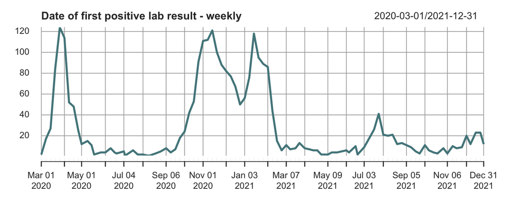

```r
FirstDate <-
  BD_chusj %>%
  select(DateOfFirstPositiveLabResult) %>%
  group_by(date = DateOfFirstPositiveLabResult) %>%
  summarise(freq = n())

FirstDate_daily   <- xts::as.xts(FirstDate$freq, order.by = as.Date(FirstDate$date))
FirstDate_weekly  <- xts::apply.weekly(FirstDate_daily, sum)

xts::plot.xts(FirstDate_weekly, col = "cadetblue4",
              lwd = 3, main = "Date of first positive lab result - weekly",
              yaxis.right = FALSE)
```

# Fig.2 - Radar Plots

Radar plots representing medication usage in subgroups: (A) ICU-admitted patients, (B) type of hospital discharge, and (C) type of MRCS. In each radar, the lines represent distinct patient categories, and the distance from each point to the origin indicates the percentage of patients using drugs from a specific ATC group. For instance, a line extending to the 75% marker under the label “ATC.A” suggests that 75% of those patients are being medicated with drugs from the ATC.A group. It’s important to note that comparisons between lines within the same radar provide insights into discrepancies in medication usage among the subgroups; however, specific values and detailed interpretation should be derived from the study’s context.

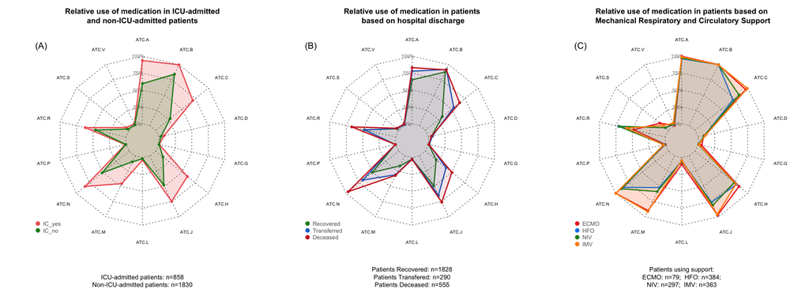

```r
#' Define function to revert order of variables in radar plot
clockwise_order <- function(ds){
  ds_rev <- ds[, c(1, ncol(ds), (ncol(ds)-1):2)]
  return(ds_rev)
}


# Define multiframe
par(mfrow = c(1, 3))
legend.x = -1.3
legend.y = -0.9


# Fig.2A - ATCs VS Intensive Care -----------------------------------------
ATCs.lv1 <- BD_chusj[, c(469, 378:390)]
ATCs.lv1 <- cbind(IntensiveCare = BD_chusj$IntensiveCare,
                  ATCs.lv1)

IC_yes_count <- ATCs.lv1$IntensiveCare[ATCs.lv1$IntensiveCare == 1] %>% length()
IC_no_count  <- ATCs.lv1$IntensiveCare[ATCs.lv1$IntensiveCare == 0] %>% length()

# Calculate the percentage of patients in and out of IC for each ATC group
ATCs.lv1 <- rbind(
  # Intensive Care == YES
  IC_yes = ATCs.lv1 %>%
    filter(IntensiveCare == 1) %>%
    {sapply(., sum) / IC_yes_count} %>%
    round(digits = 3) %>% t() %>% as.data.frame(),
  # Intensive Care == NO
  IC_no = ATCs.lv1 %>%
    filter(IntensiveCare == 0) %>%
    {sapply(., sum) / IC_no_count} %>%
    round(digits = 3) %>% t() %>% as.data.frame()
)
ATCs.lv1$IntensiveCare <- NULL

# Find max and round it (ceiling) to the nearest .1 multiple
max.axis <- plyr::round_any(max(ATCs.lv1), 0.1, f = ceiling)

# Prepare data for radar chart
ATCs.lv1 <- rbind(max = rep(max.axis, length(ATCs.lv1)),
                  min = rep(0, length(ATCs.lv1)),
                  ATCs.lv1)

# Define colors
colors <- c("indianred2", "forestgreen")
colors_border <- colors
colors_in <- scales::alpha(colors, alpha = 0.2)

# Revert order of columns
ATCs.lv1 <- clockwise_order(ATCs.lv1)

radarchart(ATCs.lv1,
           axistype = 1,
           # custom polygon
           pcol = colors_border,  # line color
           pfcol = colors_in,     # fill-in color
           plwd = 2,              # line width
           plty = 1,              # line type
           # custom the grid
           cglcol = "grey20",     # net color
           cglty = 3,             # net line type
           axislabcol = "grey50", # net label color
           cglwd = 0.8,           # net width
           caxislabels = scales::percent(seq(0, max.axis, length.out = 5)),
           # custom labels
           calcex = 0.8,
           vlcex = 0.7,
           title = "Relative use of medication in ICU-admitted\nand non-ICU-admitted patients",
           sub = paste0("ICU-admitted patients: n=", IC_yes_count, "\n",
                        "Non-ICU-admitted patients: n=", IC_no_count)
)

legend(x = legend.x,
       y = legend.y,
       legend = rownames(ATCs.lv1[-c(1,2),]),
       bty = "n",
       pch = 20,
       col = colors_border,
       text.col = "grey40",
       cex = 0.9,
       pt.cex = 2)

text(-1.2, 1.2, "(A)", cex = 1.4, pos = 1, col = "black")



# Fig.2B - ATCs vs Hospital Discharge -------------------------------------
ATCs.lv1 <- BD_chusj[, c(469, 378:390)]
ATCs.lv1 <- cbind(Outcome = BD_chusj$Outcome,
                  ATCs.lv1)

Outcome_Recovered_count    <- ATCs.lv1$Outcome[ATCs.lv1$Outcome == 0] %>% na.omit() %>% length()
Outcome_Transferred_count  <- ATCs.lv1$Outcome[ATCs.lv1$Outcome == 2] %>% na.omit() %>% length()
Outcome_Deceased_count     <- ATCs.lv1$Outcome[ATCs.lv1$Outcome == 1] %>% na.omit() %>% length()

# Calculate the percentage of patients in and out of IC for each ATC group
ATCs.lv1 <- rbind(
  Recovered    = ATCs.lv1 %>% filter(Outcome == 0) %>% {sapply(., sum) / Outcome_Recovered_count} %>% round(digits = 3) %>% t() %>% as.data.frame(),
  Transferred  = ATCs.lv1 %>% filter(Outcome == 2) %>% {sapply(., sum) / Outcome_Transferred_count} %>% round(digits = 3) %>% t() %>% as.data.frame(),
  Deceased     = ATCs.lv1 %>% filter(Outcome == 1) %>% {sapply(., sum) / Outcome_Deceased_count} %>% round(digits = 3) %>% t() %>% as.data.frame()
)
ATCs.lv1$Outcome <- NULL

# Find max and round it (ceiling) to the nearest .1 multiple
max.axis <- plyr::round_any(max(ATCs.lv1), 0.1, f = ceiling)

# Prepare data for radar chart
ATCs.lv1 <- rbind(max = rep(max.axis, length(ATCs.lv1)),
                  min = rep(0, length(ATCs.lv1)),
                  ATCs.lv1)

# Define colors
colors <- c("forestgreen", "dodgerblue3", "firebrick3")
colors_border <- colors
colors_in <- scales::alpha(colors, alpha = 0.1)

# Revert order of columns
ATCs.lv1 <- clockwise_order(ATCs.lv1)

radarchart(ATCs.lv1,
           axistype = 1,
           # custom polygon
           pcol = colors_border,  # line color
           pfcol = colors_in,     # fill-in color
           plwd = 2,              # line width
           plty = 1,              # line type
           # custom the grid
           cglcol = "grey20",   # net color
           cglty = 3,  # net line type
           axislabcol = "grey50", # net label color
           cglwd = 0.8,         # net width
           caxislabels = scales::percent(seq(0, max.axis, length.out = 5)),
           # custom labels
           calcex = 0.8,
           vlcex = 0.7,
           title = "Relative use of medication in patients\n based on hospital discharge",
           sub = paste0("Patients Recovered: n=", Outcome_Recovered_count, "\n",
                       "Patients Transfered: n=", Outcome_Transferred_count, "\n",
                       "Patients Deceased: n=", Outcome_Deceased_count)
)

legend(x = legend.x,
       y = legend.y,
       legend = rownames(ATCs.lv1[-c(1,2),]),
       bty = "n",
       pch = 20,
       col = colors_border,
       text.col = "grey40",
       cex = 0.9,
       pt.cex = 2)

text(-1.2, 1.2, "(B)", cex = 1.4, pos = 1, col = "black")





# Fig.2C - ATCs vs Respiratory Support ------------------------------------
ATCs.lv1 <- BD_chusj[, c(469, 378:390)]
ATCs.lv1 <- cbind(BD_chusj[25:28],
                  ATCs.lv1)

Support_ECMO_count <- ATCs.lv1$ECMO[ATCs.lv1$ECMO == 1] %>% na.omit() %>% length()
Support_HFO_count <- ATCs.lv1$HFO[ATCs.lv1$HFO == 1] %>% na.omit() %>% length()
Support_NIV_count <- ATCs.lv1$NIV[ATCs.lv1$NIV == 1] %>% na.omit() %>% length()
Support_IMV_count <- ATCs.lv1$IMV[ATCs.lv1$IMV == 1] %>% na.omit() %>% length()

# Calculate the percentage of patients in and out of IC for each ATC group
ATCs.lv1 <- rbind(
  ECMO = ATCs.lv1 %>% filter(ECMO == 1) %>% {sapply(., sum) / Support_ECMO_count} %>% round(digits = 3) %>% t() %>% as.data.frame(),
  HFO = ATCs.lv1 %>% filter(HFO == 1) %>% {sapply(., sum) / Support_HFO_count} %>% round(digits = 3) %>% t() %>% as.data.frame(),
  NIV = ATCs.lv1 %>% filter(NIV == 1) %>% {sapply(., sum) / Support_NIV_count} %>% round(digits = 3) %>% t() %>% as.data.frame(),
  IMV = ATCs.lv1 %>% filter(IMV == 1) %>% {sapply(., sum) / Support_IMV_count} %>% round(digits = 3) %>% t() %>% as.data.frame()
)
ATCs.lv1$ECMO <- ATCs.lv1$HFO <- ATCs.lv1$NIV <- ATCs.lv1$IMV <- NULL

# Find max and round it (ceiling) to the nearest .1 multiple
max.axis <- plyr::round_any(max(ATCs.lv1), 0.1, f = ceiling)

# Prepare data for radar chart
ATCs.lv1 <- rbind(max = rep(max.axis, length(ATCs.lv1)),
                  min = rep(0, length(ATCs.lv1)),
                  ATCs.lv1)

# Define colors
colors <- c("firebrick2", "dodgerblue2", "forestgreen", "darkorange")
colors_border <- colors
colors_in <- scales::alpha(colors, alpha = 0.1)

# Revert order of columns
ATCs.lv1 <- clockwise_order(ATCs.lv1)

radarchart(ATCs.lv1,
           axistype = 1,
           # custom polygon
           pcol = colors_border,  # line color
           pfcol = colors_in,     # fill-in color
           plwd = 2,              # line width
           plty = 1,              # line type
           # custom the grid
           cglcol = "grey20",   # net color
           cglty = 3,  # net line type
           axislabcol = "grey50", # net label color
           cglwd = 0.8,         # net width
           caxislabels = scales::percent(seq(0, max.axis, length.out = 5)),
           # custom labels
           calcex = 0.8,
           vlcex = 0.7,
           title = "Relative use of medication in patients based on\n Mechanical Respiratory and Circulatory Support",
           sub = paste0("Patients using support:\n",
                        "ECMO: n=", Support_ECMO_count, ";  ",
                        "HFO: n=", Support_HFO_count, ";\n",
                        "NIV: n=", Support_NIV_count, ";  ",
                        "IMV: n=", Support_IMV_count
           )
)

legend(x = legend.x,
       y = legend.y,
       legend = rownames(ATCs.lv1[-c(1,2),]),
       bty = "n",
       pch = 20,
       col = colors_border,
       text.col = "grey40",
       cex = 0.9,
       pt.cex = 2)

text(-1.2, 1.2, "(C)", cex = 1.4, pos = 1, col = "black")
```

```r
# Clear multiframe
par(mfrow = c(1,1))
```